# HW3

Name: Haoxin Yu

UNI: hy2747

```python
import warnings
warnings.filterwarnings('ignore')

import numpy as np
import pandas as pd
import matplotlib.pyplot as plt
import matplotlib.style as style
import seaborn as sns
import itertools
%matplotlib inline
```

```python
df = pd.read_csv('XYZloan_default_selected_vars.csv')
df = df.iloc[:, 2:]
nRow, nCol = df.shape
print(f'There are {nRow} rows and {nCol} columns')
df.head()
```

```
There are 80000 rows and 87 columns
```

|  | id | loan_default | AP001 | AP002 | AP003 | AP004 | AP005 | AP006 | AP007 | AP008 | ... | CD162 | CD164 | CD166 | CD167 | CD169 | CD170 | CD172 | CD173 | MB005 | MB007 |
| --- | --- | --- | --- | --- | --- | --- | --- | --- | --- | --- | --- | --- | --- | --- | --- | --- | --- | --- | --- | --- | --- |
| 0 | 1 | 1 | 31 | 2 | 1 | 12 | 2017/7/6 10:21 | ios | 3 | 3 | ... | 13.0 | 13.0 | 0.0 | 0.0 | 1449.0 | 1449.0 | 2249.0 | 2249.0 | 7.0 | IPHONE7 |
| 1 | 2 | 0 | 27 | 1 | 1 | 12 | 2017/4/6 12:51 | h5 | 5 | 4 | ... | -99.0 | -99.0 | -99.0 | -99.0 | -99.0 | -99.0 | -99.0 | -99.0 | NaN | WEB |
| 2 | 3 | 0 | 33 | 1 | 4 | 12 | 2017/7/1 14:11 | h5 | 4 | 2 | ... | 3.0 | 2.0 | 33.0 | 0.0 | 33.0 | 0.0 | 143.0 | 110.0 | 8.0 | WEB |
| 3 | 4 | 0 | 34 | 2 | 4 | 12 | 2017/7/7 10:10 | android | 5 | 5 | ... | 0.0 | 0.0 | 0.0 | 0.0 | 0.0 | 0.0 | 0.0 | 0.0 | 10.0 | OPPO |
| 4 | 5 | 0 | 47 | 2 | 1 | 12 | 2017/7/6 14:37 | h5 | 4 | 4 | ... | -99.0 | -99.0 | -99.0 | -99.0 | -99.0 | -99.0 | -99.0 | -99.0 | NaN | WEB |

5 rows × 87 columns

```python
selected_columns = ['id', 'loan_default', 'AP001', 'AP003', 'AP008', 'CR009', 'CR015', 'CR019', 'PA022', 'PA023', 'PA029', 'TD001', 'TD005', 'TD006', 'TD009', 'TD010', 'TD014']
df_selected = df[selected_columns]
df_selected
```

|  | id | loan_default | AP001 | AP003 | AP008 | CR009 | CR015 | CR019 | PA022 | PA023 | PA029 | TD001 | TD005 | TD006 | TD009 | TD010 | TD014 |
| --- | --- | --- | --- | --- | --- | --- | --- | --- | --- | --- | --- | --- | --- | --- | --- | --- | --- |
| 0 | 1 | 1 | 31 | 1 | 3 | 35807 | 4 | 2 | -1.0 | -1.0 | -98.0 | 1 | 4 | 1 | 5 | 1 | 2 |
| 1 | 2 | 0 | 27 | 1 | 4 | 7254 | 6 | 11 | -1.0 | -1.0 | -98.0 | 2 | 3 | 1 | 3 | 1 | 2 |
| 2 | 3 | 0 | 33 | 4 | 2 | 30377 | 2 | 3 | -1.0 | -1.0 | -98.0 | 2 | 4 | 1 | 5 | 1 | 1 |
| 3 | 4 | 0 | 34 | 4 | 5 | 0 | 5 | 8 | -1.0 | -1.0 | -98.0 | 0 | 0 | 0 | 0 | 0 | 1 |
| 4 | 5 | 0 | 47 | 1 | 4 | 0 | 6 | 11 | -99.0 | -99.0 | -99.0 | 2 | 2 | 1 | 2 | 1 | 1 |
| ... | ... | ... | ... | ... | ... | ... | ... | ... | ... | ... | ... | ... | ... | ... | ... | ... | ... |
| 79995 | 79996 | 0 | 39 | 1 | 3 | 16716 | 5 | 6 | -1.0 | -1.0 | -98.0 | 2 | 2 | 0 | 4 | 0 | 3 |
| 79996 | 79997 | 0 | 31 | 4 | 4 | 3388 | 5 | 5 | -1.0 | -1.0 | -98.0 | 0 | 2 | 0 | 2 | 0 | 0 |
| 79997 | 79998 | 0 | 37 | 1 | 3 | 0 | 3 | 6 | -1.0 | -1.0 | -98.0 | 1 | 1 | 2 | 1 | 2 | 2 |
| 79998 | 79999 | 0 | 38 | 1 | 2 | 20200 | 4 | 5 | -1.0 | -1.0 | -98.0 | 0 | 0 | 0 | 0 | 0 | 0 |
| 79999 | 80000 | 1 | 25 | 3 | 3 | 15600 | 5 | 5 | 38.0 | 38.0 | 17.4 | 5 | 8 | 4 | 8 | 6 | 6 |

80000 rows × 17 columns

```python
from sklearn.model_selection import train_test_split

# Split the data into 80% for training and 20% for testing
train_df, test_df = train_test_split(df_selected, test_size=0.2, random_state=42)
```

## Exploratory Data Analysis

### Check the value range of data columns

```python
train_df.describe()
```

|  | id | loan_default | AP001 | AP003 | AP008 | CR009 | CR015 | CR019 | PA022 | PA023 | PA029 | TD001 | TD005 | TD006 | TD009 | TD010 | TD014 |
| --- | --- | --- | --- | --- | --- | --- | --- | --- | --- | --- | --- | --- | --- | --- | --- | --- | --- |
| count | 64000.000000 | 64000.000000 | 64000.000000 | 64000.000000 | 64000.000000 | 6.400000e+04 | 64000.000000 | 64000.000000 | 63688.000000 | 63688.000000 | 63688.000000 | 64000.000000 | 64000.000000 | 64000.000000 | 64000.000000 | 64000.000000 | 64000.000000 |
| mean | 39952.275687 | 0.192781 | 31.695281 | 2.015125 | 3.115953 | 3.499405e+04 | 4.920000 | 6.190109 | 19.400923 | 14.949645 | -42.512737 | 1.985250 | 3.587000 | 1.346094 | 5.409234 | 2.020828 | 2.602719 |
| std | 23099.432039 | 0.394486 | 7.070968 | 1.196863 | 1.306930 | 6.275344e+04 | 1.094558 | 3.357364 | 39.665742 | 37.020965 | 96.963446 | 1.808095 | 2.792768 | 1.414125 | 4.011473 | 1.971726 | 2.498997 |
| min | 1.000000 | 0.000000 | 20.000000 | 1.000000 | 1.000000 | 0.000000e+00 | 2.000000 | 1.000000 | -99.000000 | -99.000000 | -99.000000 | 0.000000 | 0.000000 | 0.000000 | 0.000000 | 0.000000 | 0.000000 |
| 25% | 19883.750000 | 0.000000 | 27.000000 | 1.000000 | 2.000000 | 4.700000e+03 | 5.000000 | 3.000000 | -1.000000 | -1.000000 | -98.000000 | 1.000000 | 2.000000 | 0.000000 | 3.000000 | 1.000000 | 1.000000 |
| 50% | 39971.500000 | 0.000000 | 30.000000 | 1.000000 | 3.000000 | 1.726250e+04 | 5.000000 | 5.000000 | -1.000000 | -1.000000 | -98.000000 | 2.000000 | 3.000000 | 1.000000 | 4.000000 | 2.000000 | 2.000000 |
| 75% | 59970.250000 | 0.000000 | 35.000000 | 3.000000 | 4.000000 | 4.068000e+04 | 6.000000 | 9.000000 | 41.000000 | 14.000000 | 26.000000 | 3.000000 | 5.000000 | 2.000000 | 7.000000 | 3.000000 | 4.000000 |
| max | 80000.000000 | 1.000000 | 56.000000 | 6.000000 | 5.000000 | 1.420300e+06 | 6.000000 | 12.000000 | 448.000000 | 448.000000 | 2872.000000 | 20.000000 | 24.000000 | 21.000000 | 46.000000 | 35.000000 | 43.000000 |

```python
train_df['loan_default'].value_counts()
```

```
0    51662
1    12338
Name: loan_default, dtype: int64
```

### Check value distribution of each columns

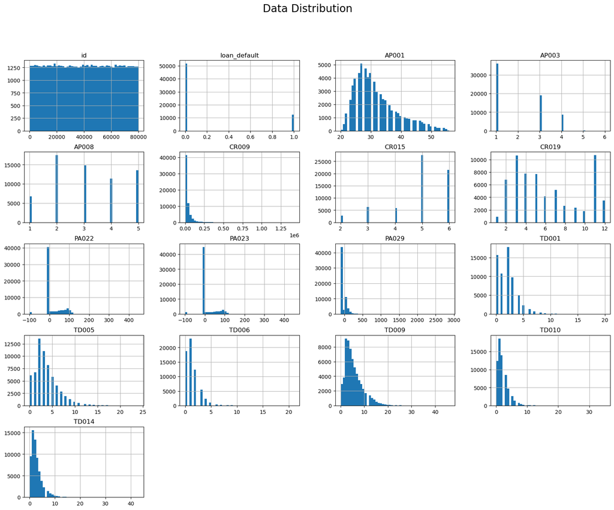

```python
import matplotlib.pyplot as plt

def plot_distribution(train_df, title):
    train_df.hist(bins=50, figsize=(20,15))
    plt.suptitle(title, fontsize=20)
    plt.show()

plot_distribution(train_df, 'Data Distribution')
```

### Split a continuous variable into a categorial variable

```python
def binning(var):
    train_df[var + '_bin'] = pd.qcut(train_df[var],10,duplicates='drop').values.add_categories("NoData")
    train_df[var + '_bin'] = train_df[var + '_bin'].fillna("NoData").astype(str)
    train_df[var + '_bin'].value_counts(dropna=False)

to_bin_features = ['AP003', 'AP008', 'CR009', 'CR015', 'CR019', 'PA022', 'PA023', 'PA029', 'TD001', 'TD005', 'TD006', 'TD009', 'TD010', 'TD014']
for i in to_bin_features:
    binning(i)

features_bin = [f + '_bin' for f in to_bin_features]
features_bin
```

```
['AP003_bin',
 'AP008_bin',
 'CR009_bin',
 'CR015_bin',
 'CR019_bin',
 'PA022_bin',
 'PA023_bin',
 'PA029_bin',
 'TD001_bin',
 'TD005_bin',
 'TD006_bin',
 'TD009_bin',
 'TD010_bin',
 'TD014_bin']
```

```python
def apply_binning(var, bins):
    test_df[var + '_bin'] = pd.cut(test_df[var], bins=bins, include_lowest=True, duplicates='drop').astype(str)
    test_df[var + '_bin'] = test_df[var + '_bin'].fillna("NoData")

to_bin_features = ['AP003', 'AP008', 'CR009', 'CR015', 'CR019', 'PA022', 'PA023', 'PA029', 'TD001', 'TD005', 'TD006', 'TD009', 'TD010', 'TD014']
bins_dict = {}

# Apply binning for each feature using the bins created from training
for feature in to_bin_features:
    bins, _ = pd.qcut(train_df[feature], 10, duplicates='drop', retbins=True)
    bins = pd.Categorical(bins).categories
    bins_dict[feature] = bins
    apply_binning(feature, bins_dict[feature])

# Create the list of bin features for the testing dataset
features_bin = [f + '_bin' for f in to_bin_features]
```

### Plot the % of Y by X

```python
def plot_X_and_Y(var):
    import matplotlib
    import matplotlib.pyplot as plt
    import numpy as np

    z= train_df.groupby(var)['loan_default'].agg(['count','mean']).reset_index()
    z['count_pcnt'] = z['count']/z['count'].sum()
    x = z[var]
    y_mean = z['mean']
    count_pcnt = z['count_pcnt']
    ind = np.arange(0, len(x))
    width = .5

    fig = plt.figure(figsize=(16,4))
    plt.subplot(121)
    plt.bar(ind, count_pcnt, width, color='r')
    plt.ylabel('X')
    plt.title(var + ' Distribution')
    plt.xticks(ind,x.tolist(), rotation=45)

    plt.subplot(122)
    plt.plot(ind, y_mean, width, color='b')
    plt.ylabel('Y by X')
    plt.xticks(ind,x.tolist(), rotation=45)
    plt.tight_layout()
    plt.title('Response mean by ' + var)
    plt.show()
```

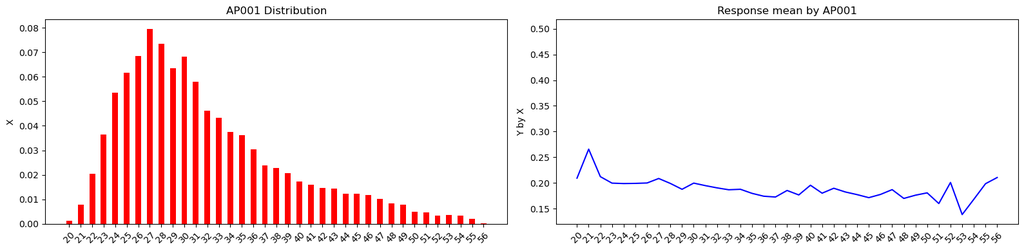

```python
plot_X_and_Y('AP001')
```

The variable 'AP001', which stands for 'YR_AGE', represents the age of loan borrowers. When examining the relationship between 'YR_AGE' and 'loan_default', it is observed that as the 'AP001' increases (indicating older individuals), the likelihood of 'loan_default' decreases. This suggests that older individuals tend to have a lower likelihood of defaulting on loans compared to younger individuals.

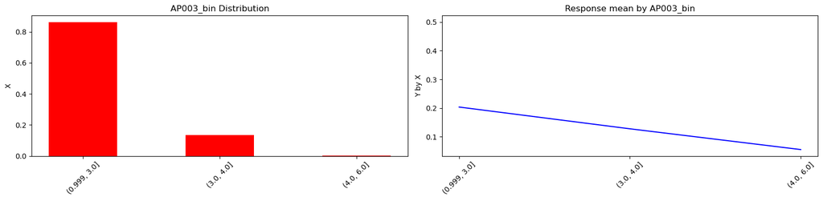

```python
plot_X_and_Y('AP003_bin')
```

The variable 'AP003', which stands for "Code Education', represents the education level of loan borrowers. When examining the relationship between 'AP003' and 'loan_default', it is observed that as the 'Code Education' increases (indicating individuals with higher education), the likelihood of 'loan_default' decreases. This suggests that individuals with higher education tend to have a lower likelihood of defaulting on loans compared to individuals with lower education.

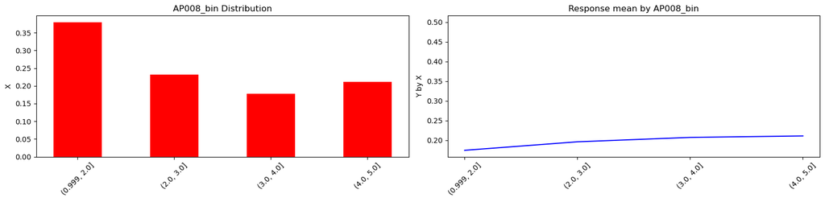

```python
plot_X_and_Y('AP008_bin')
```

The variable 'AP008', which stands for 'FLAG_IP_CITY_NOT_APPL_CITY', indicates whether the IP address match the city mentioned in the application. When examining the relationship between 'AP008' and 'loan_default', it is observed that as the 'AP008' increases, the likelihood of 'loan_default' increases. This suggests that discrepancies between the IP address and stated city in the application may be indicative of a higher risk of loan default.

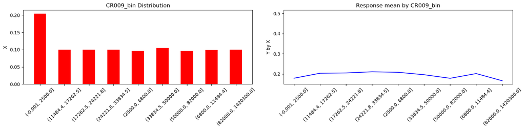

```python
plot_X_and_Y('CR009_bin')
```

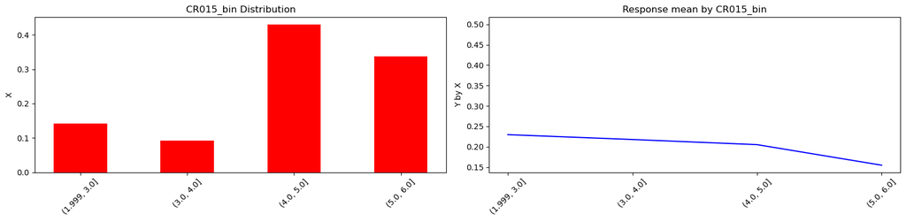

```python
plot_X_and_Y('CR015_bin')
```

The variable 'CR015', which stands for 'MONTH_CREDIT_CARD_MOB_MAX', represents the maximum number of months the credit card associated with the account has been active. When examining the relationship between 'CR015' and 'loan_default', it is observed that as the 'CR015' increases (indicating a longer credit card usage history), the likelihood of 'loan_default' decreases. This suggests that accounts with a more extended credit card history may be indicative of a lower risk of loan default.

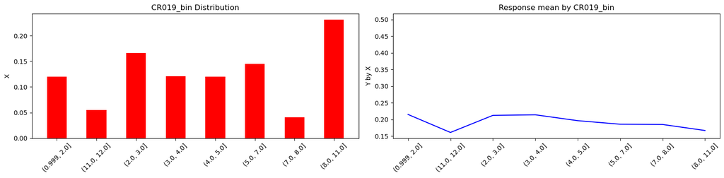

```python
plot_X_and_Y('CR019_bin')
```

The variable 'CR019', which stands for 'SCORE_SINGLE_DEBIT_CARD_LIMIT', represents the credit scoring score for the limit of a single debit card. When examining the relationship between 'CR019' and 'loan_default', it is observed that as the 'CR019' increases (indicating a higher spending score), the likelihood of 'loan_default' decreases. This suggests that accounts with a higher spending score fot the limit of a single debit card may be indicative of a lower risk of loan default.

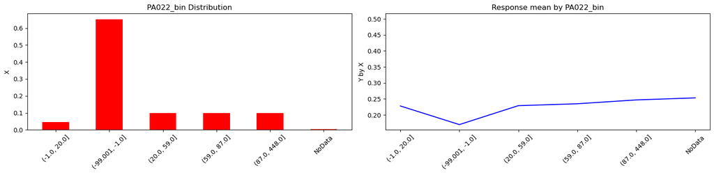

```python
plot_X_and_Y('PA022_bin')
```

The variable 'PA022', which stands for 'DAYS_BTW_APPLICATION_AND_FIRST_COLLECTION_OR_HIGH_RISK_CALL', represents the number of days between the loan application date and the date of the first collection or high-risk call. When examining the relationship between 'PA022' and 'loan_default', it is observed that as the 'PA022' increases (indicating a longer duration between application and first collection/high-risk call), the likelihood of 'loan_default' increases. This suggests that accounts with a longer duration between application and collection/call activity may have a higher risk of loan default.

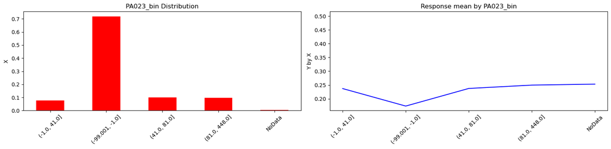

```python
plot_X_and_Y('PA023_bin')
```

The variable 'PA023', which stands for 'DAYS_BTW_APPLICATION_AND_FIRST_COLLECTION__CALL', represents the number of days between the loan application date and the date of the first collection call. When examining the relationship between 'PA023' and 'loan_default', it is observed that as the 'PA023' increases (indicating a longer duration between application and first collection call), the likelihood of 'loan_default' increases. This suggests that accounts with a longer duration between application and collection call activity may have a higher risk of loan default.

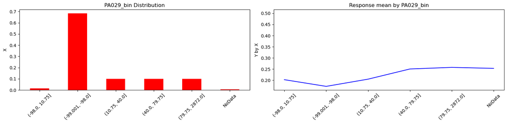

```python
plot_X_and_Y('PA029_bin')
```

The variable 'PA029', which stands for 'AVG_LEN_COLLECTION_OR_HIGH_RISK_INBOUND_CALLS', represents the average length of collection or high-risk inbound calls associated with the loan. When analyzing the relationship between 'PA029' and 'loan_default', it is observed that as the 'PA029' value increases (indicating a longer average call duration), the likelihood of 'loan_default' increases. This suggests that accounts with longer average call durations for collection or high-risk inbound calls may have a higher risk of loan default.

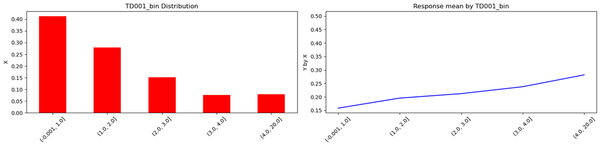

```python
plot_X_and_Y('TD001_bin')
```

The variable 'TD001', which stands for 'TD_CNT_QUERY_LAST_7Day_P2P', represents the count of queries made within the last 7 days related to peer-to-peer transactions. When analyzing the relationship between 'TD001' and 'loan_default', it is observed that as the 'TD001' value increases (indicating a higher number of queries made), the likelihood of 'loan_default' increases. This suggests that accounts with a higher number of queries related to peer-to-peer transactions within the last 7 days may have a higher risk of loan default.

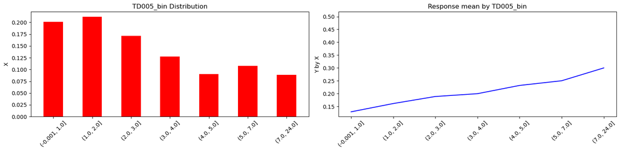

```python
plot_X_and_Y('TD005_bin')
```

The variable 'TD005', which stands for 'TD_CNT_QUERY_LAST_1MON_P2P', represents the count of queries made within the last 1 month related to peer-to-peer transactions. When analyzing the relationship between 'TD005' and 'loan_default', it is observed that as the 'TD005' value increases (indicating a higher number of queries made), the likelihood of 'loan_default' increases. This suggests that accounts with a higher number of queries related to peer-to-peer transactions within the last 1 month may have a higher risk of loan default.

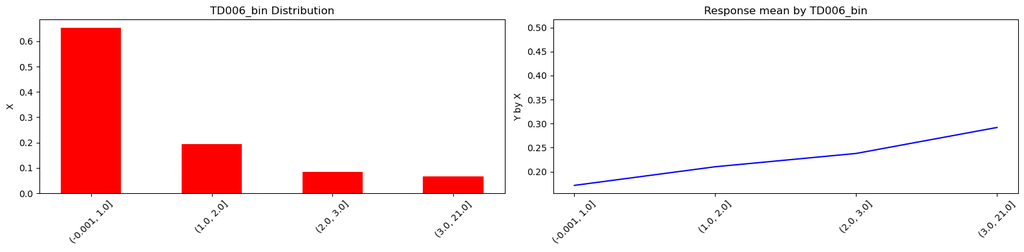

```python
plot_X_and_Y('TD006_bin')
```

The variable 'TD006', which stands for 'TD_CNT_QUERY_LAST_1MON_SMALL_LOAN', represents the count of queries made within the last 1 month related to small loans. When examining the relationship between 'TD006' and 'loan_default', it is observed that as the 'TD006' value increases (indicating a higher number of queries made), the likelihood of 'loan_default' increases as well. This suggests that accounts with a higher number of queries related to small loans within the last 1 month may be associated with a higher risk of loan default.

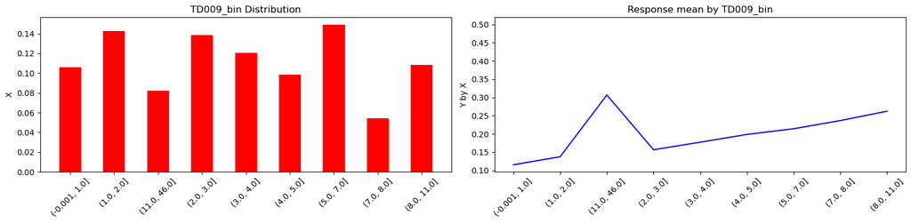

```python
plot_X_and_Y('TD009_bin')
```

The variable 'TD009', which stands for 'TD_CNT_QUERY_LAST_3MON_P2P', represents the count of queries made within the last 3 months related to peer-to-peer transactions. When analyzing the relationship between 'TD009' and 'loan_default', it is observed that as the 'TD009' value increases (indicating a higher number of queries made), the likelihood of 'loan_default' increases as well. This suggests that accounts with a higher number of queries related to P2P transactions within the last 3 months may be associated with a higher risk of loan default.

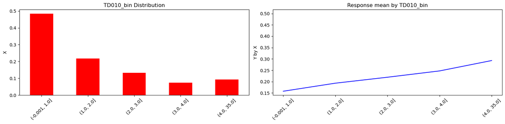

```python
plot_X_and_Y('TD010_bin')
```

The variable 'TD010', which stands for 'TD_CNT_QUERY_LAST_3MON_SMALL_LOAN', represents the count of queries made within the last 3 months related to small loans. When analyzing the relationship between 'TD010' and 'loan_default', it is observed that as the 'TD010' value increases (indicating a higher number of queries made), the likelihood of 'loan_default' increases as well. This suggests that accounts with a higher number of queries related to small loans within the last 3 months may be associated with a higher risk of loan default.

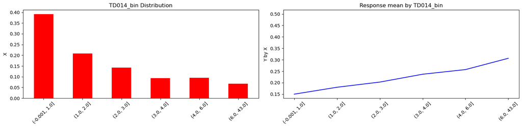

```python
plot_X_and_Y('TD014_bin')
```

The variable 'TD014', which stands for 'TD_CNT_QUERY_LAST_6MON_SMALL_LOAN', represents the count of queries made within the last 6 months related to small loans. When analyzing the relationship between 'TD014' and 'loan_default', it is observed that as the 'TD014' value increases (indicating a higher number of queries made), the likelihood of 'loan_default' also tends to increase. This suggests that accounts with a higher number of queries related to small loans within the last 6 months may be associated with a higher risk of loan default.

## Feature Engineering: weight-of-evidence (WOE) transformation

```python
def WOE(var):
    train_df[var] = train_df[var].fillna('NoData')
    k = train_df[[var,'loan_default']].groupby(var)['loan_default'].agg(['count','sum']).reset_index()
    k.columns = [var,'Count','Good']
    k['Bad'] = k['Count'] - k['Good']
    k['Good %'] = (k['Good'] / k['Good'].sum()*100).round(2)
    k['Bad %'] = (k['Bad'] / k['Bad'].sum()*100).round(2)
    k[var+'_WOE'] = np.log(k['Good %'] / k['Bad %']).round(2)
    k = k.sort_values(by=var+'_WOE')
    return(k)
```

```python
k = WOE('AP001')
k.head()
```

|  | AP001 | Count | Good | Bad | Good % | Bad % | AP001_WOE |
| --- | --- | --- | --- | --- | --- | --- | --- |
| 33 | 53 | 224 | 31 | 193 | 0.25 | 0.37 | -0.39 |
| 31 | 51 | 294 | 47 | 247 | 0.38 | 0.48 | -0.23 |
| 34 | 54 | 220 | 37 | 183 | 0.30 | 0.35 | -0.15 |
| 28 | 48 | 530 | 90 | 440 | 0.73 | 0.85 | -0.15 |
| 25 | 45 | 788 | 135 | 653 | 1.09 | 1.26 | -0.14 |

```python
df1 = pd.merge(train_df[['id','loan_default','AP001']],k[['AP001','AP001_WOE']],
     left_on='AP001',
     right_on='AP001',how='left')
```

```python
df1_test = pd.merge(test_df[['id','loan_default','AP001']],k[['AP001','AP001_WOE']],
     left_on='AP001',
     right_on='AP001',how='left')
```

```python
k = WOE('AP003_bin')
k
```

|  | AP003_bin | Count | Good | Bad | Good % | Bad % | AP003_bin_WOE |
| --- | --- | --- | --- | --- | --- | --- | --- |
| 2 | (4.0, 6.0] | 199 | 11 | 188 | 0.09 | 0.36 | -1.39 |
| 1 | (3.0, 4.0] | 8672 | 1107 | 7565 | 8.97 | 14.64 | -0.49 |
| 0 | (0.999, 3.0] | 55129 | 11220 | 43909 | 90.94 | 84.99 | 0.07 |

```python
df2 = pd.merge(train_df[['id','AP003','AP003_bin']],k[['AP003_bin','AP003_bin_WOE']],
     left_on='AP003_bin',
     right_on='AP003_bin',how='left')
```

```python
df2_test = pd.merge(test_df[['id','AP003','AP003_bin']],k[['AP003_bin','AP003_bin_WOE']],
     left_on='AP003_bin',
     right_on='AP003_bin',how='left')
```

```python
k = WOE('AP008_bin')
k
```

|  | AP008_bin | Count | Good | Bad | Good % | Bad % | AP008_bin_WOE |
| --- | --- | --- | --- | --- | --- | --- | --- |
| 0 | (0.999, 2.0] | 24258 | 4226 | 20032 | 34.25 | 38.78 | -0.12 |
| 1 | (2.0, 3.0] | 14818 | 2902 | 11916 | 23.52 | 23.07 | 0.02 |
| 2 | (3.0, 4.0] | 11381 | 2356 | 9025 | 19.10 | 17.47 | 0.09 |
| 3 | (4.0, 5.0] | 13543 | 2854 | 10689 | 23.13 | 20.69 | 0.11 |

```python
df3 = pd.merge(train_df[['id', 'AP008','AP008_bin']],k[['AP008_bin','AP008_bin_WOE']],
     left_on='AP008_bin',
     right_on='AP008_bin',how='left')
```

```python
df3_test = pd.merge(test_df[['id', 'AP008','AP008_bin']],k[['AP008_bin','AP008_bin_WOE']],
     left_on='AP008_bin',
     right_on='AP008_bin',how='left')
```

```python
k = WOE('CR009_bin')
k
```

|  | CR009_bin | Count | Good | Bad | Good % | Bad % | CR009_bin_WOE |
| --- | --- | --- | --- | --- | --- | --- | --- |
| 8 | (82000.0, 1420300.0] | 6393 | 1063 | 5330 | 8.62 | 10.32 | -0.18 |
| 0 | (-0.001, 2500.0] | 13072 | 2338 | 10734 | 18.95 | 20.78 | -0.09 |
| 6 | (50000.0, 82000.0] | 6135 | 1095 | 5040 | 8.88 | 9.76 | -0.09 |
| 5 | (33834.5, 50000.0] | 6672 | 1309 | 5363 | 10.61 | 10.38 | 0.02 |
| 7 | (6800.0, 11484.4] | 6358 | 1284 | 5074 | 10.41 | 9.82 | 0.06 |
| 1 | (11484.4, 17262.5] | 6400 | 1303 | 5097 | 10.56 | 9.87 | 0.07 |
| 2 | (17262.5, 24221.8] | 6400 | 1312 | 5088 | 10.63 | 9.85 | 0.08 |
| 4 | (2500.0, 6800.0] | 6170 | 1285 | 4885 | 10.41 | 9.46 | 0.10 |
| 3 | (24221.8, 33834.5] | 6400 | 1349 | 5051 | 10.93 | 9.78 | 0.11 |

```python
df4 = pd.merge(train_df[['id','CR009','CR009_bin']],k[['CR009_bin','CR009_bin_WOE']],
     left_on='CR009_bin',
     right_on='CR009_bin',how='left')
```

```python
df4_test = pd.merge(test_df[['id','CR009','CR009_bin']],k[['CR009_bin','CR009_bin_WOE']],
     left_on='CR009_bin',
     right_on='CR009_bin',how='left')
```

```python
k = WOE('CR015_bin')
k
```

|  | CR015_bin | Count | Good | Bad | Good % | Bad % | CR015_bin_WOE |
| --- | --- | --- | --- | --- | --- | --- | --- |
| 3 | (5.0, 6.0] | 21562 | 3337 | 18225 | 27.05 | 35.28 | -0.27 |
| 2 | (4.0, 5.0] | 27500 | 5641 | 21859 | 45.72 | 42.31 | 0.08 |
| 1 | (3.0, 4.0] | 5870 | 1278 | 4592 | 10.36 | 8.89 | 0.15 |
| 0 | (1.999, 3.0] | 9068 | 2082 | 6986 | 16.87 | 13.52 | 0.22 |

```python
df5 = pd.merge(train_df[['id','CR015','CR015_bin']],k[['CR015_bin','CR015_bin_WOE']],
     left_on='CR015_bin',
     right_on='CR015_bin',how='left')
```

```python
df5_test = pd.merge(test_df[['id','CR015','CR015_bin']],k[['CR015_bin','CR015_bin_WOE']],
     left_on='CR015_bin',
     right_on='CR015_bin',how='left')
```

```python
k = WOE('CR019_bin')
k
```

|  | CR019_bin | Count | Good | Bad | Good % | Bad % | CR019_bin_WOE |
| --- | --- | --- | --- | --- | --- | --- | --- |
| 1 | (11.0, 12.0] | 3499 | 564 | 2935 | 4.57 | 5.68 | -0.22 |
| 7 | (8.0, 11.0] | 14804 | 2473 | 12331 | 20.04 | 23.87 | -0.17 |
| 6 | (7.0, 8.0] | 2615 | 484 | 2131 | 3.92 | 4.12 | -0.05 |
| 5 | (5.0, 7.0] | 9286 | 1726 | 7560 | 13.99 | 14.63 | -0.04 |
| 4 | (4.0, 5.0] | 7699 | 1513 | 6186 | 12.26 | 11.97 | 0.02 |
| 2 | (2.0, 3.0] | 10654 | 2263 | 8391 | 18.34 | 16.24 | 0.12 |
| 3 | (3.0, 4.0] | 7761 | 1662 | 6099 | 13.47 | 11.81 | 0.13 |
| 0 | (0.999, 2.0] | 7682 | 1653 | 6029 | 13.40 | 11.67 | 0.14 |

```python
df6 = pd.merge(train_df[['id','CR019', 'CR019_bin']],k[['CR019_bin','CR019_bin_WOE']],
     left_on='CR019_bin',
     right_on='CR019_bin',how='left')
```

```python
df6_test = pd.merge(test_df[['id','CR019','CR019_bin']],k[['CR019_bin','CR019_bin_WOE']],
     left_on='CR019_bin',
     right_on='CR019_bin',how='left')
```

```python
k = WOE('PA022_bin')
k
```

|  | PA022_bin | Count | Good | Bad | Good % | Bad % | PA022_bin_WOE |
| --- | --- | --- | --- | --- | --- | --- | --- |
| 1 | (-99.001, -1.0] | 41766 | 7093 | 34673 | 57.49 | 67.12 | -0.15 |
| 0 | (-1.0, 20.0] | 2896 | 660 | 2236 | 5.35 | 4.33 | 0.21 |
| 2 | (20.0, 59.0] | 6382 | 1461 | 4921 | 11.84 | 9.53 | 0.22 |
| 3 | (59.0, 87.0] | 6353 | 1492 | 4861 | 12.09 | 9.41 | 0.25 |
| 4 | (87.0, 448.0] | 6291 | 1553 | 4738 | 12.59 | 9.17 | 0.32 |
| 5 | NoData | 312 | 79 | 233 | 0.64 | 0.45 | 0.35 |

```python
df7 = pd.merge(train_df[['id','PA022','PA022_bin']],k[['PA022_bin','PA022_bin_WOE']],
     left_on='PA022_bin',
     right_on='PA022_bin',how='left')
```

```python
df7_test = pd.merge(test_df[['id','PA022','PA022_bin']],k[['PA022_bin','PA022_bin_WOE']],
     left_on='PA022_bin',
     right_on='PA022_bin',how='left')
```

```python
k = WOE('PA023_bin')
k
```

|  | PA023_bin | Count | Good | Bad | Good % | Bad % | PA023_bin_WOE |
| --- | --- | --- | --- | --- | --- | --- | --- |
| 1 | (-99.001, -1.0] | 46059 | 7997 | 38062 | 64.82 | 73.68 | -0.13 |
| 0 | (-1.0, 41.0] | 4914 | 1165 | 3749 | 9.44 | 7.26 | 0.26 |
| 2 | (41.0, 81.0] | 6403 | 1521 | 4882 | 12.33 | 9.45 | 0.27 |
| 3 | (81.0, 448.0] | 6312 | 1576 | 4736 | 12.77 | 9.17 | 0.33 |
| 4 | NoData | 312 | 79 | 233 | 0.64 | 0.45 | 0.35 |

```python
df8 = pd.merge(train_df[['id','PA023','PA023_bin']],k[['PA023_bin','PA023_bin_WOE']],
     left_on='PA023_bin',
     right_on='PA023_bin',how='left')
```

```python
df8_test = pd.merge(test_df[['id','PA023','PA023_bin']],k[['PA023_bin','PA023_bin_WOE']],
     left_on='PA023_bin',
     right_on='PA023_bin',how='left')
```

```python
k = WOE('PA029_bin')
k
```

|  | PA029_bin | Count | Good | Bad | Good % | Bad % | PA029_bin_WOE |
| --- | --- | --- | --- | --- | --- | --- | --- |
| 1 | (-99.001, -98.0] | 43718 | 7545 | 36173 | 61.15 | 70.02 | -0.14 |
| 0 | (-98.0, 10.75] | 864 | 175 | 689 | 1.42 | 1.33 | 0.07 |
| 2 | (10.75, 40.0] | 6432 | 1318 | 5114 | 10.68 | 9.90 | 0.08 |
| 3 | (40.0, 79.75] | 6307 | 1580 | 4727 | 12.81 | 9.15 | 0.34 |
| 5 | NoData | 312 | 79 | 233 | 0.64 | 0.45 | 0.35 |
| 4 | (79.75, 2872.0] | 6367 | 1641 | 4726 | 13.30 | 9.15 | 0.37 |

```python
df9 = pd.merge(train_df[['id','PA029','PA029_bin']],k[['PA029_bin','PA029_bin_WOE']],
     left_on='PA029_bin',
     right_on='PA029_bin',how='left')
```

```python
df9_test = pd.merge(test_df[['id','PA029','PA029_bin']],k[['PA029_bin','PA029_bin_WOE']],
     left_on='PA029_bin',
     right_on='PA029_bin',how='left')
```

```python
k = WOE('TD001_bin')
k
```

|  | TD001_bin | Count | Good | Bad | Good % | Bad % | TD001_bin_WOE |
| --- | --- | --- | --- | --- | --- | --- | --- |
| 0 | (-0.001, 1.0] | 26405 | 4178 | 22227 | 33.86 | 43.02 | -0.24 |
| 1 | (1.0, 2.0] | 17835 | 3487 | 14348 | 28.26 | 27.77 | 0.02 |
| 2 | (2.0, 3.0] | 9755 | 2069 | 7686 | 16.77 | 14.88 | 0.12 |
| 3 | (3.0, 4.0] | 4891 | 1163 | 3728 | 9.43 | 7.22 | 0.27 |
| 4 | (4.0, 20.0] | 5114 | 1441 | 3673 | 11.68 | 7.11 | 0.50 |

```python
df10 = pd.merge(train_df[['id','TD001','TD001_bin']],k[['TD001_bin','TD001_bin_WOE']],
     left_on='TD001_bin',
     right_on='TD001_bin',how='left')
```

```python
df10_test = pd.merge(test_df[['id','TD001','TD001_bin']],k[['TD001_bin','TD001_bin_WOE']],
     left_on='TD001_bin',
     right_on='TD001_bin',how='left')
```

```python
k = WOE('TD005_bin')
k
```

|  | TD005_bin | Count | Good | Bad | Good % | Bad % | TD005_bin_WOE |
| --- | --- | --- | --- | --- | --- | --- | --- |
| 0 | (-0.001, 1.0] | 12892 | 1665 | 11227 | 13.49 | 21.73 | -0.48 |
| 1 | (1.0, 2.0] | 13559 | 2188 | 11371 | 17.73 | 22.01 | -0.22 |
| 2 | (2.0, 3.0] | 10995 | 2076 | 8919 | 16.83 | 17.26 | -0.03 |
| 3 | (3.0, 4.0] | 8174 | 1633 | 6541 | 13.24 | 12.66 | 0.04 |
| 4 | (4.0, 5.0] | 5779 | 1340 | 4439 | 10.86 | 8.59 | 0.23 |
| 5 | (5.0, 7.0] | 6916 | 1730 | 5186 | 14.02 | 10.04 | 0.33 |
| 6 | (7.0, 24.0] | 5685 | 1706 | 3979 | 13.83 | 7.70 | 0.59 |

```python
df11 = pd.merge(train_df[['id','TD005','TD005_bin']],k[['TD005_bin','TD005_bin_WOE']],
     left_on='TD005_bin',
     right_on='TD005_bin',how='left')
```

```python
df11_test = pd.merge(test_df[['id','TD005','TD005_bin']],k[['TD005_bin','TD005_bin_WOE']],
     left_on='TD005_bin',
     right_on='TD005_bin',how='left')
```

```python
k = WOE('TD006_bin')
k
```

|  | TD006_bin | Count | Good | Bad | Good % | Bad % | TD006_bin_WOE |
| --- | --- | --- | --- | --- | --- | --- | --- |
| 0 | (-0.001, 1.0] | 41782 | 7162 | 34620 | 58.05 | 67.01 | -0.14 |
| 1 | (1.0, 2.0] | 12417 | 2610 | 9807 | 21.15 | 18.98 | 0.11 |
| 2 | (2.0, 3.0] | 5461 | 1299 | 4162 | 10.53 | 8.06 | 0.27 |
| 3 | (3.0, 21.0] | 4340 | 1267 | 3073 | 10.27 | 5.95 | 0.55 |

```python
df12 = pd.merge(train_df[['id','TD006','TD006_bin']],k[['TD006_bin','TD006_bin_WOE']],
     left_on='TD006_bin',
     right_on='TD006_bin',how='left')
```

```python
df12_test = pd.merge(test_df[['id','TD006','TD006_bin']],k[['TD006_bin','TD006_bin_WOE']],
     left_on='TD006_bin',
     right_on='TD006_bin',how='left')
```

```python
k = WOE('TD009_bin')
k
```

|  | TD009_bin | Count | Good | Bad | Good % | Bad % | TD009_bin_WOE |
| --- | --- | --- | --- | --- | --- | --- | --- |
| 0 | (-0.001, 1.0] | 6789 | 783 | 6006 | 6.35 | 11.63 | -0.61 |
| 1 | (1.0, 2.0] | 9131 | 1255 | 7876 | 10.17 | 15.25 | -0.41 |
| 3 | (2.0, 3.0] | 8864 | 1388 | 7476 | 11.25 | 14.47 | -0.25 |
| 4 | (3.0, 4.0] | 7712 | 1367 | 6345 | 11.08 | 12.28 | -0.10 |
| 5 | (4.0, 5.0] | 6316 | 1254 | 5062 | 10.16 | 9.80 | 0.04 |
| 6 | (5.0, 7.0] | 9537 | 2042 | 7495 | 16.55 | 14.51 | 0.13 |
| 7 | (7.0, 8.0] | 3458 | 818 | 2640 | 6.63 | 5.11 | 0.26 |
| 8 | (8.0, 11.0] | 6932 | 1818 | 5114 | 14.73 | 9.90 | 0.40 |
| 2 | (11.0, 46.0] | 5261 | 1613 | 3648 | 13.07 | 7.06 | 0.62 |

```python
df13 = pd.merge(train_df[['id','TD009','TD009_bin']],k[['TD009_bin','TD009_bin_WOE']],
     left_on='TD009_bin',
     right_on='TD009_bin',how='left')
```

```python
df13_test = pd.merge(test_df[['id','TD009','TD009_bin']],k[['TD009_bin','TD009_bin_WOE']],
     left_on='TD009_bin',
     right_on='TD009_bin',how='left')
```

```python
k = WOE('TD010_bin')
k
```

|  | TD010_bin | Count | Good | Bad | Good % | Bad % | TD010_bin_WOE |
| --- | --- | --- | --- | --- | --- | --- | --- |
| 0 | (-0.001, 1.0] | 30969 | 4887 | 26082 | 39.61 | 50.49 | -0.24 |
| 1 | (1.0, 2.0] | 13916 | 2689 | 11227 | 21.79 | 21.73 | 0.00 |
| 2 | (2.0, 3.0] | 8472 | 1859 | 6613 | 15.07 | 12.80 | 0.16 |
| 3 | (3.0, 4.0] | 4696 | 1161 | 3535 | 9.41 | 6.84 | 0.32 |
| 4 | (4.0, 35.0] | 5947 | 1742 | 4205 | 14.12 | 8.14 | 0.55 |

```python
df14 = pd.merge(train_df[['id','TD010','TD010_bin']],k[['TD010_bin','TD010_bin_WOE']],
     left_on='TD010_bin',
     right_on='TD010_bin',how='left')
```

```python
df14_test = pd.merge(test_df[['id','TD010','TD010_bin']],k[['TD010_bin','TD010_bin_WOE']],
     left_on='TD010_bin',
     right_on='TD010_bin',how='left')
```

```python
k = WOE('TD014_bin')
k
```

|  | TD014_bin | Count | Good | Bad | Good % | Bad % | TD014_bin_WOE |
| --- | --- | --- | --- | --- | --- | --- | --- |
| 0 | (-0.001, 1.0] | 25059 | 3757 | 21302 | 30.45 | 41.23 | -0.30 |
| 1 | (1.0, 2.0] | 13366 | 2407 | 10959 | 19.51 | 21.21 | -0.08 |
| 2 | (2.0, 3.0] | 9156 | 1856 | 7300 | 15.04 | 14.13 | 0.06 |
| 3 | (3.0, 4.0] | 5967 | 1414 | 4553 | 11.46 | 8.81 | 0.26 |
| 4 | (4.0, 6.0] | 6087 | 1566 | 4521 | 12.69 | 8.75 | 0.37 |
| 5 | (6.0, 43.0] | 4365 | 1338 | 3027 | 10.84 | 5.86 | 0.62 |

```python
df15 = pd.merge(train_df[['id','TD014','TD014_bin']],k[['TD014_bin','TD014_bin_WOE']],
     left_on='TD014_bin',
     right_on='TD014_bin',how='left')
```

```python
df15_test = pd.merge(test_df[['id','TD014','TD014_bin']],k[['TD014_bin','TD014_bin_WOE']],
     left_on='TD014_bin',
     right_on='TD014_bin',how='left')
```

```python
from functools import reduce

#define list of DataFrames
dfs = [df1, df2, df3, df4, df5, df6, df7, df8, df9, df10, df11, df12, df13, df14, df15]

#merge all DataFrames into one
train_df = reduce(lambda  left,right: pd.merge(left,right,on=['id'],
                                            how='outer'), dfs)

#view merged DataFrame
train_df.head()
```

|  | id | loan_default | AP001 | AP001_WOE | AP003 | AP003_bin | AP003_bin_WOE | AP008 | AP008_bin | AP008_bin_WOE | ... | TD006_bin_WOE | TD009 | TD009_bin | TD009_bin_WOE | TD010 | TD010_bin | TD010_bin_WOE | TD014 | TD014_bin | TD014_bin_WOE |
| --- | --- | --- | --- | --- | --- | --- | --- | --- | --- | --- | --- | --- | --- | --- | --- | --- | --- | --- | --- | --- | --- |
| 0 | 3823 | 0 | 29 | -0.03 | 4 | (3.0, 4.0] | -0.49 | 2 | (0.999, 2.0] | -0.12 | ... | 0.27 | 14 | (11.0, 46.0] | 0.62 | 5 | (4.0, 35.0] | 0.55 | 5 | (4.0, 6.0] | 0.37 |
| 1 | 35563 | 1 | 47 | -0.04 | 1 | (0.999, 3.0] | 0.07 | 2 | (0.999, 2.0] | -0.12 | ... | -0.14 | 2 | (1.0, 2.0] | -0.41 | 1 | (-0.001, 1.0] | -0.24 | 1 | (-0.001, 1.0] | -0.30 |
| 2 | 4884 | 0 | 31 | 0.01 | 1 | (0.999, 3.0] | 0.07 | 5 | (4.0, 5.0] | 0.11 | ... | -0.14 | 6 | (5.0, 7.0] | 0.13 | 2 | (1.0, 2.0] | 0.00 | 2 | (1.0, 2.0] | -0.08 |
| 3 | 71171 | 0 | 29 | -0.03 | 3 | (0.999, 3.0] | 0.07 | 4 | (3.0, 4.0] | 0.09 | ... | 0.27 | 9 | (8.0, 11.0] | 0.40 | 3 | (2.0, 3.0] | 0.16 | 3 | (2.0, 3.0] | 0.06 |
| 4 | 25666 | 0 | 35 | -0.09 | 4 | (3.0, 4.0] | -0.49 | 3 | (2.0, 3.0] | 0.02 | ... | -0.14 | 2 | (1.0, 2.0] | -0.41 | 0 | (-0.001, 1.0] | -0.24 | 0 | (-0.001, 1.0] | -0.30 |

5 rows × 46 columns

```python
train_df.shape
```

```
(64000, 46)
```

```python
train_df.columns
```

```
Index(['id', 'loan_default', 'AP001', 'AP001_WOE', 'AP003', 'AP003_bin',
       'AP003_bin_WOE', 'AP008', 'AP008_bin', 'AP008_bin_WOE', 'CR009',
       'CR009_bin', 'CR009_bin_WOE', 'CR015', 'CR015_bin', 'CR015_bin_WOE',
       'CR019', 'CR019_bin', 'CR019_bin_WOE', 'PA022', 'PA022_bin',
       'PA022_bin_WOE', 'PA023', 'PA023_bin', 'PA023_bin_WOE', 'PA029',
       'PA029_bin', 'PA029_bin_WOE', 'TD001', 'TD001_bin', 'TD001_bin_WOE',
       'TD005', 'TD005_bin', 'TD005_bin_WOE', 'TD006', 'TD006_bin',
       'TD006_bin_WOE', 'TD009', 'TD009_bin', 'TD009_bin_WOE', 'TD010',
       'TD010_bin', 'TD010_bin_WOE', 'TD014', 'TD014_bin', 'TD014_bin_WOE'],
      dtype='object')
```

```python
from functools import reduce

#define list of DataFrames
dfs = [df1_test, df2_test, df3_test, df4_test, df5_test, df6_test, df7_test, df8_test, df9_test, df10_test, df11_test, df12_test, df13_test, df14_test, df15_test]

#merge all DataFrames into one
test_df = reduce(lambda  left,right: pd.merge(left,right,on=['id'],
                                            how='outer'), dfs)

#view merged DataFrame
test_df.head()
```

|  | id | loan_default | AP001 | AP001_WOE | AP003 | AP003_bin | AP003_bin_WOE | AP008 | AP008_bin | AP008_bin_WOE | ... | TD006_bin_WOE | TD009 | TD009_bin | TD009_bin_WOE | TD010 | TD010_bin | TD010_bin_WOE | TD014 | TD014_bin | TD014_bin_WOE |
| --- | --- | --- | --- | --- | --- | --- | --- | --- | --- | --- | --- | --- | --- | --- | --- | --- | --- | --- | --- | --- | --- |
| 0 | 47045 | 0 | 30 | 0.04 | 3 | (0.999, 3.0] | 0.07 | 3 | (2.0, 3.0] | 0.02 | ... | -0.14 | 2 | (1.0, 2.0] | -0.41 | 1 | (-0.001, 1.0] | -0.24 | 1 | (-0.001, 1.0] | -0.30 |
| 1 | 44296 | 0 | 33 | -0.04 | 3 | (0.999, 3.0] | 0.07 | 5 | (4.0, 5.0] | 0.11 | ... | -0.14 | 7 | (5.0, 7.0] | 0.13 | 1 | (-0.001, 1.0] | -0.24 | 2 | (1.0, 2.0] | -0.08 |
| 2 | 74784 | 0 | 29 | -0.03 | 4 | (3.0, 4.0] | -0.49 | 5 | (4.0, 5.0] | 0.11 | ... | -0.14 | 4 | (3.0, 4.0] | -0.10 | 1 | (-0.001, 1.0] | -0.24 | 1 | (-0.001, 1.0] | -0.30 |
| 3 | 70976 | 1 | 28 | 0.04 | 1 | (0.999, 3.0] | 0.07 | 5 | (4.0, 5.0] | 0.11 | ... | 0.27 | 1 | (-0.001, 1.0] | -0.61 | 3 | (2.0, 3.0] | 0.16 | 4 | (3.0, 4.0] | 0.26 |
| 4 | 46646 | 0 | 27 | 0.10 | 1 | (0.999, 3.0] | 0.07 | 3 | (2.0, 3.0] | 0.02 | ... | 0.11 | 15 | (11.0, 46.0] | 0.62 | 5 | (4.0, 35.0] | 0.55 | 6 | (4.0, 6.0] | 0.37 |

5 rows × 46 columns

```python
test_df.shape
```

```
(16000, 46)
```

```python
test_df.columns
```

```
Index(['id', 'loan_default', 'AP001', 'AP001_WOE', 'AP003', 'AP003_bin',
       'AP003_bin_WOE', 'AP008', 'AP008_bin', 'AP008_bin_WOE', 'CR009',
       'CR009_bin', 'CR009_bin_WOE', 'CR015', 'CR015_bin', 'CR015_bin_WOE',
       'CR019', 'CR019_bin', 'CR019_bin_WOE', 'PA022', 'PA022_bin',
       'PA022_bin_WOE', 'PA023', 'PA023_bin', 'PA023_bin_WOE', 'PA029',
       'PA029_bin', 'PA029_bin_WOE', 'TD001', 'TD001_bin', 'TD001_bin_WOE',
       'TD005', 'TD005_bin', 'TD005_bin_WOE', 'TD006', 'TD006_bin',
       'TD006_bin_WOE', 'TD009', 'TD009_bin', 'TD009_bin_WOE', 'TD010',
       'TD010_bin', 'TD010_bin_WOE', 'TD014', 'TD014_bin', 'TD014_bin_WOE'],
      dtype='object')
```

## Decision tree

### Simple Model

```python
from sklearn.tree import DecisionTreeClassifier # for classification
from sklearn.tree import DecisionTreeRegressor # for regression

# First, specify the model.
dtree = DecisionTreeClassifier()
```

```python
X_train = train_df[['AP001', 'AP003', 'AP008', 'CR009', 'CR015', 'CR019', 'PA022', 'PA023', 'PA029', 'TD001', 'TD005', 'TD006', 'TD009', 'TD010', 'TD014']]
Y_train = train_df['loan_default']
```

```python
X_test = test_df[['AP001', 'AP003', 'AP008', 'CR009', 'CR015', 'CR019', 'PA022', 'PA023', 'PA029', 'TD001', 'TD005', 'TD006', 'TD009', 'TD010', 'TD014']]
Y_test = test_df['loan_default']
```

```python
for col in X_train:
    X_train.loc[:,col].fillna(X_train.loc[:,col].mean(),inplace=True)
```

```python
dtree.fit(X_train,Y_train)
```

```
DecisionTreeClassifier()
```

```python
importances = pd.DataFrame({'feature': X_train.columns, 'importance': np.round(dtree.feature_importances_,3)})
importances = importances.sort_values('importance',ascending=False)
importances
```

|  | feature | importance |
| --- | --- | --- |
| 3 | CR009 | 0.189 |
| 0 | AP001 | 0.127 |
| 5 | CR019 | 0.092 |
| 12 | TD009 | 0.070 |
| 8 | PA029 | 0.063 |
| 2 | AP008 | 0.061 |
| 10 | TD005 | 0.058 |
| 6 | PA022 | 0.056 |
| 9 | TD001 | 0.056 |
| 14 | TD014 | 0.056 |
| 7 | PA023 | 0.044 |
| 11 | TD006 | 0.043 |
| 13 | TD010 | 0.040 |
| 4 | CR015 | 0.031 |
| 1 | AP003 | 0.015 |

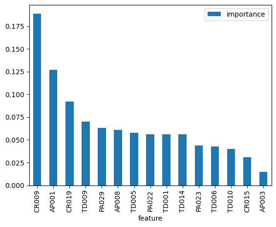

```python
importances.plot.bar(x='feature')
```

```python
predictions = dtree.predict(X_test[0:10])
predictions
```

```
array([1, 0, 0, 0, 0, 0, 0, 0, 1, 0])
```

```python
dtree.predict_proba(X_test[0:10])
```

```
array([[0., 1.],
       [1., 0.],
       [1., 0.],
       [1., 0.],
       [1., 0.],
       [1., 0.],
       [1., 0.],
       [1., 0.],
       [0., 1.],
       [1., 0.]])
```

```python
y_pred = dtree.predict_proba(X_test[0:10])[:,1]
y_pred
```

```
array([1., 0., 0., 0., 0., 0., 0., 0., 1., 0.])
```

```python
for col in X_test:
    X_test.loc[:,col].fillna(X_test.loc[:,col].mean(),inplace=True)
```

```python
import matplotlib.pyplot as plt
from sklearn.metrics import roc_curve,roc_auc_score

y_pred = dtree.predict_proba(X_test)[:,1]
roc_auc_value = roc_auc_score(Y_test,y_pred)
roc_auc_value
```

```
0.5269885738990796
```

```python
fpr, tpr, _ = roc_curve(Y_test, y_pred)
[fpr,tpr]
```

```
[array([0.        , 0.2044358 , 0.20490272, 0.20536965, 1.        ]),
 array([0.        , 0.25809524, 0.25904762, 0.25936508, 1.        ])]
```

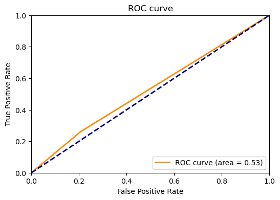

```python
import matplotlib.pyplot as plt
lw=2
plt.figure(figsize=(6,4))
plt.plot(fpr,tpr, color='darkorange',lw=lw,label='ROC curve (area = %0.2f)' %roc_auc_value)
plt.plot([0,1],[0,1], color='navy',lw=lw,linestyle='--')
plt.xlim([0,1])
plt.ylim([0,1])
plt.xlabel('False Positive Rate')
plt.ylabel('True Positive Rate')
plt.title('ROC curve')
plt.legend(loc='lower right')
plt.show()
```

### Advanced Model

```python
from sklearn.tree import DecisionTreeClassifier # for classification
from sklearn.tree import DecisionTreeRegressor # for regression

# First, specify the model.
dtree = DecisionTreeClassifier(min_samples_leaf = 5, max_depth = 6)
```

```python
X_train = train_df[['AP001_WOE', 'AP003_bin_WOE', 'AP008_bin_WOE', 'CR009_bin_WOE', 'CR015_bin_WOE', 'CR019_bin_WOE', 'PA022_bin_WOE', 'PA023_bin_WOE', 'PA029_bin_WOE', 'TD001_bin_WOE', 'TD005_bin_WOE', 'TD006_bin_WOE', 'TD009_bin_WOE', 'TD010_bin_WOE', 'TD014_bin_WOE']]
Y_train = train_df['loan_default']
```

```python
X_test = test_df[['AP001_WOE', 'AP003_bin_WOE', 'AP008_bin_WOE', 'CR009_bin_WOE', 'CR015_bin_WOE', 'CR019_bin_WOE', 'PA022_bin_WOE', 'PA023_bin_WOE', 'PA029_bin_WOE', 'TD001_bin_WOE', 'TD005_bin_WOE', 'TD006_bin_WOE', 'TD009_bin_WOE', 'TD010_bin_WOE', 'TD014_bin_WOE']]
Y_test = test_df['loan_default']
```

```python
# Then, train the model.
dtree.fit(X_train,Y_train)
```

```
DecisionTreeClassifier(max_depth=6, min_samples_leaf=5)
```

```python
importances = pd.DataFrame({'feature': X_train.columns, 'importance': np.round(dtree.feature_importances_,3)})
importances = importances.sort_values('importance',ascending=False)
importances
```

|  | feature | importance |
| --- | --- | --- |
| 12 | TD009_bin_WOE | 0.437 |
| 1 | AP003_bin_WOE | 0.155 |
| 4 | CR015_bin_WOE | 0.109 |
| 14 | TD014_bin_WOE | 0.050 |
| 2 | AP008_bin_WOE | 0.042 |
| 8 | PA029_bin_WOE | 0.042 |
| 7 | PA023_bin_WOE | 0.041 |
| 6 | PA022_bin_WOE | 0.030 |
| 10 | TD005_bin_WOE | 0.023 |
| 9 | TD001_bin_WOE | 0.022 |
| 0 | AP001_WOE | 0.014 |
| 5 | CR019_bin_WOE | 0.014 |
| 3 | CR009_bin_WOE | 0.009 |
| 11 | TD006_bin_WOE | 0.009 |
| 13 | TD010_bin_WOE | 0.002 |

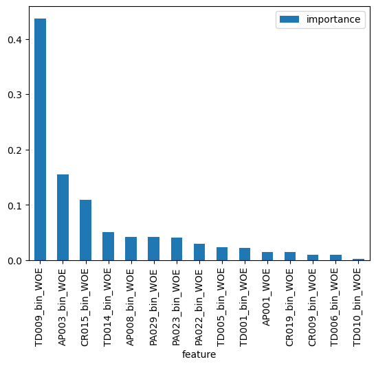

```python
importances.plot.bar(x='feature')
```

```python
for col in X_test:
    X_test.loc[:,col].fillna(X_test.loc[:,col].mean(),inplace=True)
```

```python
predictions = dtree.predict(X_test[0:10])
```

```python
dtree.predict_proba(X_test[0:10])
```

```
array([[0.86491295, 0.13508705],
       [0.79348411, 0.20651589],
       [0.88888889, 0.11111111],
       [0.76190476, 0.23809524],
       [0.65268065, 0.34731935],
       [0.88547486, 0.11452514],
       [0.67293626, 0.32706374],
       [0.82666116, 0.17333884],
       [0.74327628, 0.25672372],
       [0.75859744, 0.24140256]])
```

```python
import matplotlib.pyplot as plt
from sklearn.metrics import roc_curve,roc_auc_score

y_pred = dtree.predict_proba(X_test)[:,1]
roc_auc_value = roc_auc_score(Y_test,y_pred)
roc_auc_value
```

```
0.6300946328207027
```

```python
fpr, tpr, _ = roc_curve(Y_test, y_pred)
[fpr,tpr]
```

```
[array([0.00000000e+00, 7.00389105e-04, 1.01167315e-03, 2.64591440e-03,
        1.03501946e-02, 1.15175097e-02, 1.19844358e-02, 2.14007782e-02,
        2.33463035e-02, 4.60700389e-02, 4.78599222e-02, 5.96108949e-02,
        6.47470817e-02, 6.57587549e-02, 9.49416342e-02, 1.10194553e-01,
        1.15719844e-01, 1.58287938e-01, 2.06070039e-01, 2.20311284e-01,
        2.21556420e-01, 2.22256809e-01, 2.43035019e-01, 2.49883268e-01,
        2.54319066e-01, 2.73696498e-01, 2.92217899e-01, 3.02101167e-01,
        3.03424125e-01, 3.10116732e-01, 3.65836576e-01, 3.74708171e-01,
        3.77120623e-01, 3.88482490e-01, 3.93385214e-01, 4.17120623e-01,
        5.28015564e-01, 5.41400778e-01, 5.42334630e-01, 5.46770428e-01,
        5.92918288e-01, 5.97898833e-01, 6.41556420e-01, 6.55097276e-01,
        6.58054475e-01, 6.62879377e-01, 7.95097276e-01, 8.06536965e-01,
        8.10350195e-01, 8.16498054e-01, 8.27859922e-01, 8.45214008e-01,
        8.55408560e-01, 9.29027237e-01, 9.42023346e-01, 9.44435798e-01,
        9.49649805e-01, 9.63035019e-01, 9.81945525e-01, 9.88015564e-01,
        9.90116732e-01, 1.00000000e+00]),
 array([0.00000000e+00, 3.17460317e-04, 6.34920635e-04, 3.17460317e-03,
        2.15873016e-02, 2.28571429e-02, 2.28571429e-02, 3.96825397e-02,
        4.06349206e-02, 8.88888889e-02, 9.33333333e-02, 1.22539683e-01,
        1.29523810e-01, 1.30476190e-01, 1.90158730e-01, 2.12380952e-01,
        2.19047619e-01, 3.00634921e-01, 3.63492063e-01, 3.80634921e-01,
        3.81904762e-01, 3.82857143e-01, 4.09841270e-01, 4.21587302e-01,
        4.28888889e-01, 4.51746032e-01, 4.75873016e-01, 4.86031746e-01,
        4.86349206e-01, 4.91111111e-01, 5.55238095e-01, 5.64761905e-01,
        5.68253968e-01, 5.80952381e-01, 5.86349206e-01, 6.06031746e-01,
        7.15555556e-01, 7.30158730e-01, 7.30793651e-01, 7.34603175e-01,
        7.69206349e-01, 7.72063492e-01, 7.99365079e-01, 8.05079365e-01,
        8.07301587e-01, 8.10476190e-01, 9.05714286e-01, 9.13333333e-01,
        9.16825397e-01, 9.20952381e-01, 9.24761905e-01, 9.34285714e-01,
        9.36825397e-01, 9.69841270e-01, 9.77777778e-01, 9.79047619e-01,
        9.80952381e-01, 9.85396825e-01, 9.93015873e-01, 9.96190476e-01,
        9.98095238e-01, 1.00000000e+00])]
```

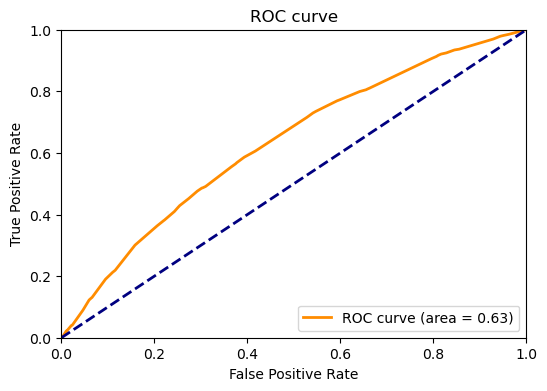

```python
import matplotlib.pyplot as plt
lw=2
plt.figure(figsize=(6,4))
plt.plot(fpr,tpr, color='darkorange',lw=lw,label='ROC curve (area = %0.2f)' %roc_auc_value)
plt.plot([0,1],[0,1], color='navy',lw=lw,linestyle='--')
plt.xlim([0,1])
plt.ylim([0,1])
plt.xlabel('False Positive Rate')
plt.ylabel('True Positive Rate')
plt.title('ROC curve')
plt.legend(loc='lower right')
plt.show()
```

The feature transformation using Weight of Evidence (WOE) has improved the model's performance, as shown by an increase in the ROC score. The baseline model had an ROC of 0.53, while the model after WOE transformation achieved an improved ROC of 0.63. The increase in the ROC score from 0.53 to 0.63 suggests that the improved model has a better overall predictive ability and is more effective at distinguishing between default and non-default cases.